# Script 2 - Spatio-temporal patterns of infection

Blood parasites and avian health

Marie Buysse, Mathilde Ollagnier, Charly Souc, Marjorie Bruley, Thomas Blanchon, Carole Leray, Marion Vittecoq and Karen D. McCoy

# 0.Librairies

```r
library(readxl) #read_excel function
library(ggplot2)
library(dplyr) #filter function
library(lme4) #glmer function
library(MuMIn) #dredge function
library(kableExtra) #kable function
library(sjPlot) #tab_model function
library(DHARMa) #simulateResiduals function
library(mgcv) #gam function
library(gratia) #derivatives function
library(spdep) #for spatial auto-correlation analysis
library(sf) #st_as_sf and st_distance functions
library(spdep) #knn2nb function
```

# 1.Spatial auto-correlation of the probability of infection

Using a separate data file for each colony, year, and group (nests, then only chicks) (see `rawdata_spatial analysis` directpry), we first convert nest coordinates (x,y) to obtain approximate distances in meters between nest locations. We then use this data to create a spatial weights matrix for analyzing relationships between nest locations We define a neighbourhood size of 20 meters between nests and allowed for isolated nest locations. We expect infected clusters to occur at this spatial scale:

```r
nests <- read.csv("carteau2023_juv.csv",sep = ";", dec = ".")
num_locations <- nrow(nests)
print (num_locations)
```

```
## [1] 19
```

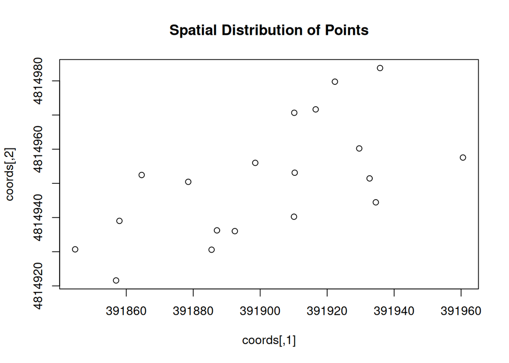

```r
lat_to_meters <- function(lat) lat * 111000
lon_to_meters <- function(lon, lat) lon * 111000 * cos(lat * pi / 180)

nests$x_meters <- lon_to_meters(nests$x, nests$y)
nests$y_meters <- lat_to_meters(nests$y)

# Create spatial weights
coords <- cbind(nests$x_meters, nests$y_meters)
max_dist <- 20 # Adjust based on your study area
weights <- dnearneigh(coords, 0, max_dist)
weights_list <- nb2listw(weights, style="W", zero.policy = TRUE)

plot(coords, main="Spatial Distribution of Points")
```

We then examine the distances between nests by creating a distance matrix. We visualise these pairwise distances to validate the defined neighbourhood size:

```r
nest_sf <- st_as_sf(nests, coords = c("x_meters", "y_meters"))
dist_matrix <- st_distance(nest_sf)

coords <- cbind(nests$x_meters, nests$y_meters)
knn1 <- knn2nb(knearneigh(coords, k=1))
```

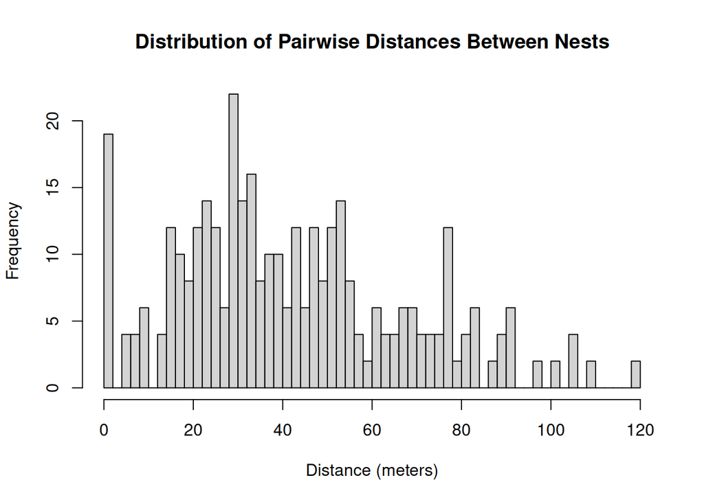

```r
max_nn_dist <- max(unlist(nbdists(knn1, coords)))

hist(as.vector(dist_matrix), breaks = 50,
     main = "Distribution of Pairwise Distances Between Nests",
     xlab = "Distance (meters)")
```

```r
summary(as.vector(dist_matrix))
```

```
##    Min. 1st Qu.  Median    Mean 3rd Qu.    Max.
##    0.00   23.52   37.81   42.30   56.31  118.90
```

We next convert the variable ‘infected’ into a categorical variable related to each location. This defines whether a location was positive or negative for Babesia infection. When considering the ‘nid’ datasets, a nest was positive if either the adult or a chick from the nest was infected. For the ‘juv’ datasets, we only considered whether chicks were infected or not. This data is analysed for spatial autocorrelation using a Monte Carlo simulation of Join Count statistics, comparing the number of Infected-Infected, Uninfected-Uninfected, and Infected-Uninfected nest pairs to what would be expected by chance (null distribution from 999 simulations):

```r
# Convert infected to a factor
nests$infected <- factor(nests$infected, levels = c(0, 1), labels = c("Uninfected", "Infected"))

# Optional: Monte Carlo version for more robust results
jc_mc <- joincount.mc(nests$infected, weights_list, nsim = 999, zero.policy = TRUE)
print(jc_mc)
```

```
##
##  Monte-Carlo simulation of join-count statistic
##
## data:  nests$infected
## weights: weights_list
## number of simulations + 1: 1000
##
## Join-count statistic for Uninfected = 2.125, rank of observed statistic
## = 978, p-value = 0.022
## alternative hypothesis: greater
## sample estimates:
##     mean of simulation variance of simulation
##              1.1232900              0.2241241
##
##
##  Monte-Carlo simulation of join-count statistic
##
## data:  nests$infected
## weights: weights_list
## number of simulations + 1: 1000
##
## Join-count statistic for Infected = 4, rank of observed statistic =
## 787, p-value = 0.213
## alternative hypothesis: greater
## sample estimates:
##     mean of simulation variance of simulation
##              3.4931598              0.3591786
```

```r
str(jc_mc)
```

```
## List of 2
##  $ :List of 8
##   ..$ statistic  : Named num 2.12
##   .. ..- attr(*, "names")= chr "Join-count statistic for Uninfected"
##   ..$ parameter  : Named num 978
##   .. ..- attr(*, "names")= chr "rank of observed statistic"
##   ..$ method     : chr "Monte-Carlo simulation of join-count statistic"
##   ..$ data.name  : chr "nests$infected \nweights: weights_list \nnumber of simulations + 1: 1000 \n"
##   ..$ p.value    : num 0.022
##   ..$ alternative: chr "greater"
##   ..$ estimate   : Named num [1:2] 1.123 0.224
##   .. ..- attr(*, "names")= chr [1:2] "mean of simulation" "variance of simulation"
##   ..$ res        : num [1:1000] 2 0.542 1.208 0.667 1.375 ...
##   ..- attr(*, "class")= chr [1:2] "htest" "mc.sim"
##  $ :List of 8
##   ..$ statistic  : Named num 4
##   .. ..- attr(*, "names")= chr "Join-count statistic for Infected"
##   ..$ parameter  : Named num 787
##   .. ..- attr(*, "names")= chr "rank of observed statistic"
##   ..$ method     : chr "Monte-Carlo simulation of join-count statistic"
##   ..$ data.name  : chr "nests$infected \nweights: weights_list \nnumber of simulations + 1: 1000 \n"
##   ..$ p.value    : num 0.213
##   ..$ alternative: chr "greater"
##   ..$ estimate   : Named num [1:2] 3.493 0.359
##   .. ..- attr(*, "names")= chr [1:2] "mean of simulation" "variance of simulation"
##   ..$ res        : num [1:1000] 4.08 3.12 3.12 2.96 2.83 ...
##   ..- attr(*, "class")= chr [1:2] "htest" "mc.sim"
##  - attr(*, "class")= chr "jclist"
```

This step visualises the results:

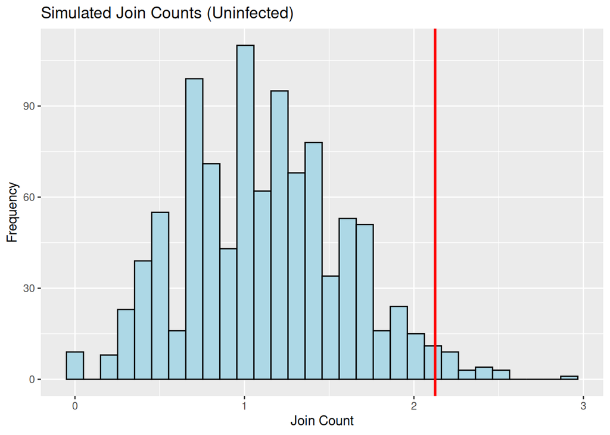

```r
# For Uninfected
ggplot(data.frame(sim = jc_mc[[1]]$res), aes(x = sim)) +
  geom_histogram(bins = 30, fill = "lightblue", color = "black") +
  geom_vline(xintercept = jc_mc[[1]]$statistic, color = "red", size = 1) +
  labs(title = "Simulated Join Counts (Uninfected)",
       x = "Join Count",
       y = "Frequency")
```

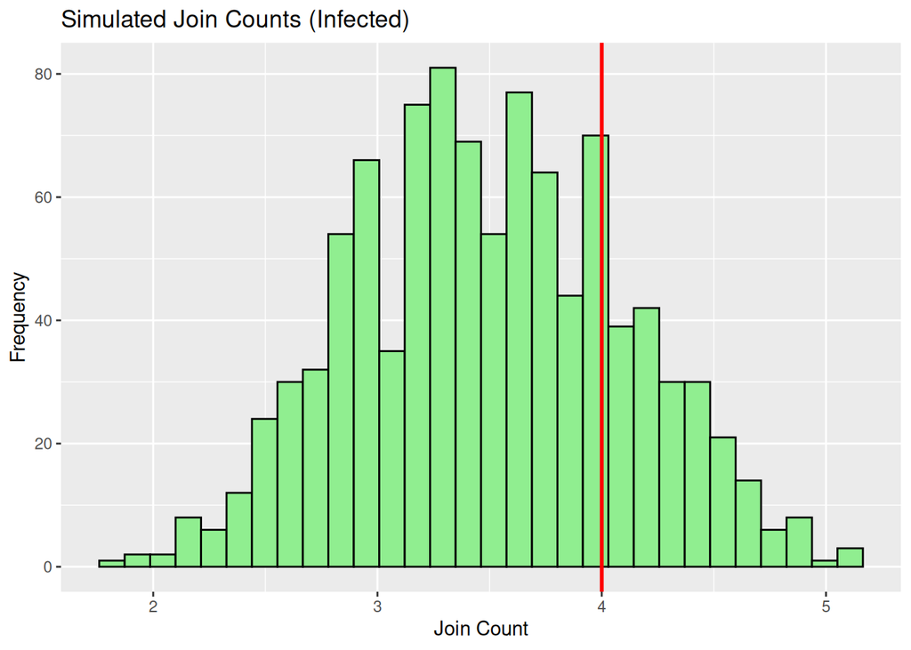

```r
# For Infected
ggplot(data.frame(sim = jc_mc[[2]]$res), aes(x = sim)) +
  geom_histogram(bins = 30, fill = "lightgreen", color = "black") +
  geom_vline(xintercept = jc_mc[[2]]$statistic, color = "red", size = 1) +
  labs(title = "Simulated Join Counts (Infected)",
       x = "Join Count",
       y = "Frequency")
```

# 2.Factors influencing the probability of infection

## 2.0. Dataset and prevalence data

```r
data_prev<- read_excel("Data_Spatio-temporal patterns of infection_infection_factors.xlsx")
data_prev$Site <- as.factor(data_prev$Site)
data_prev$Year <- as.factor(data_prev$Year)
data_prev$Age <- as.factor(data_prev$Age)
data_prev$Smear <- as.factor(data_prev$Smear)
data_prev$Sex <- as.factor(data_prev$Sex)
data_prev$qPCR <- as.factor(data_prev$qPCR)
data_prev$Nest <- as.factor(data_prev$Nest)
data_prev$Ticks_by_nest <- as.numeric(data_prev$Ticks_by_nest)
```

With:  
-Site: sampling colony (Carteau/Frioul)  
-Sample: ID of individual bird  
-Year: sampling year (2022/2023/2024)  
-Age: age of bird (Chick/Adult)  
-Smear: infection status based on blood smears technique (uninfected = 0/infected = 1)  
-Sex: sex of bird (F/M)  
-qPCR: infection status based on qPCR technique (uninfected = 0/infected = 1)  
-Nest: nest of bird  
-Ticks_by_nest: number of ticks collected in the nest

We compute the prevalence data for each detection dataset (`Smear` and `qPCR` according to `Age`, `Year` and `Site`).  
For the `Smear` dataset:

```r
smear_dataset <- data_prev %>%
  filter(Smear %in% c(0,1))

prevalence_smear <- smear_dataset %>%
  group_by(Site, Year, Age) %>%
  summarise(
    n_total = n(),
    n_positive = sum(Smear == 1, na.rm = TRUE),
    prevalence = (n_positive / n_total) * 100)

kable(prevalence_smear, align = "lllccc")
```

| Site | Year | Age | n_total | n_positive | prevalence |
| --- | --- | --- | --- | --- | --- |
| Carteau | 2022 | Adult | 20 | 1 | 5.000000 |
| Carteau | 2022 | Chick | 20 | 16 | 80.000000 |
| Carteau | 2023 | Adult | 20 | 0 | 0.000000 |
| Carteau | 2023 | Chick | 25 | 9 | 36.000000 |
| Carteau | 2024 | Adult | 16 | 1 | 6.250000 |
| Carteau | 2024 | Chick | 15 | 14 | 93.333333 |
| Frioul | 2022 | Adult | 17 | 0 | 0.000000 |
| Frioul | 2022 | Chick | 21 | 0 | 0.000000 |
| Frioul | 2023 | Adult | 17 | 1 | 5.882353 |
| Frioul | 2023 | Chick | 22 | 3 | 13.636364 |
| Frioul | 2024 | Adult | 20 | 3 | 15.000000 |
| Frioul | 2024 | Chick | 19 | 7 | 36.842105 |

For the `qPCR` dataset:

```r
qPCR_dataset <- data_prev %>%
  filter(qPCR %in% c(0,1))

prevalence_qPCR <- qPCR_dataset %>%
  group_by(Site, Year, Age) %>%
  summarise(
    n_total = n(),
    n_positive = sum(qPCR == 1, na.rm = TRUE),
    prevalence = (n_positive / n_total) * 100)

kable(prevalence_qPCR, align = "lllccc")
```

| Site | Year | Age | n_total | n_positive | prevalence |
| --- | --- | --- | --- | --- | --- |
| Carteau | 2022 | Adult | 17 | 2 | 11.764706 |
| Carteau | 2022 | Chick | 15 | 9 | 60.000000 |
| Carteau | 2023 | Adult | 19 | 1 | 5.263158 |
| Carteau | 2023 | Chick | 25 | 15 | 60.000000 |
| Carteau | 2024 | Adult | 17 | 3 | 17.647059 |
| Carteau | 2024 | Chick | 17 | 15 | 88.235294 |
| Frioul | 2022 | Adult | 14 | 1 | 7.142857 |
| Frioul | 2022 | Chick | 18 | 1 | 5.555556 |
| Frioul | 2023 | Adult | 17 | 1 | 5.882353 |
| Frioul | 2023 | Chick | 23 | 2 | 8.695652 |
| Frioul | 2024 | Adult | 20 | 2 | 10.000000 |
| Frioul | 2024 | Chick | 20 | 5 | 25.000000 |

We calculate the prevalence for all chicks and all adults:

```r
prevalence_qPCR_ad_ch <- qPCR_dataset %>%
  group_by(Age) %>%
  summarise(
    n_total = n(),
    n_positive = sum(qPCR == 1, na.rm = TRUE),
    prevalence = (n_positive / n_total) * 100,
    SE = sqrt((n_positive / n_total) * (1 - (n_positive / n_total)) / n_total) * 100)

kable(prevalence_qPCR_ad_ch, align = "lllcc")
```

| Age | n_total | n_positive | prevalence | SE |
| --- | --- | --- | --- | --- |
| Adult | 104 | 10 | 9.615385 | 2.890773 |
| Chick | 118 | 47 | 39.830509 | 4.506663 |

We remove the missing values of variables that will be analysed in the model and create two data subsets (one for chicks, one for adults):

```r
data_model <- data_prev[!(is.na(data_prev$Nest)), ]
data_model <- data_model[!(is.na(data_model$qPCR)), ]
data_model <- data_model[!(is.na(data_model$Ticks_by_nest)), ]

data_chicks_model <- filter(data_model, Age == "Chick")
data_adults_model <- filter(data_model, Age == "Adult")
data_adults_model <- data_adults_model[!(is.na(data_adults_model$Sex)), ]
```

## 2.1.Factors influencing the probability of infection of adults

We include the variables `Sex`, `Year`, `Site`, and `Ticks_by_nest` as fixed effects and `Nest` as a random effect in our analyses based on GLMER model (binomial family). As the full model is complex, we first proceed by comparing null model to single-variable models:

```r
glmer_null_adults <-glmer(qPCR ~ 1 + (1|Nest), family=binomial(link = "logit"), data=data_adults_model)
glmer_year_adults <-glmer(qPCR ~ Year + (1|Nest), family=binomial(link = "logit"), data=data_adults_model)
glmer_site_adults <-glmer(qPCR ~ Site + (1|Nest), family=binomial(link = "logit"), data=data_adults_model)
glmer_ticks_adults <-glmer(qPCR ~ Ticks_by_nest + (1|Nest), family=binomial(link = "logit"), data=data_adults_model)
glmer_sex_adults <-glmer(qPCR ~ Sex + (1|Nest), family=binomial(link = "logit"), data=data_adults_model)

anova1 <- anova(glmer_null_adults, glmer_year_adults, test="Chisq")
anova2 <- anova(glmer_null_adults, glmer_site_adults, test="Chisq")
anova3 <- anova(glmer_null_adults, glmer_ticks_adults, test="Chisq")
anova4 <- anova(glmer_null_adults, glmer_sex_adults, test="Chisq")

p_value_anova1 <- anova1$`Pr(>Chisq)`[2]
p_value_anova2 <- anova2$`Pr(>Chisq)`[2]
p_value_anova3 <- anova3$`Pr(>Chisq)`[2]
p_value_anova4 <- anova4$`Pr(>Chisq)`[2]

anova_results_prev_ad_1 <- data.frame(
  Comparison = c("glmer_null",
                 "glmer_null vs Year",
                 "glmer_null vs Site",
                 "glmer_null vs Ticks_by_nest",
                 "glmer_null vs Sex"),
  ANOVA_p_value = c("-", p_value_anova1, p_value_anova2, p_value_anova3, p_value_anova4),
  AICc = c(AICc(glmer_null_adults), AICc(glmer_year_adults), AICc(glmer_site_adults), AICc(glmer_ticks_adults), AICc(glmer_sex_adults)))

# Print the table with kable
anova_results_prev_ad_1 %>%
  kable(caption = "Results of comparison between glmer_null_adults and single-variable models") %>%
  kable_styling(bootstrap_options = c("striped", "hover", "condensed", "responsive"))
```

Results of comparison between glmer_null_adults and single-variable models

Comparison

ANOVA_p_value

AICc

glmer_null

32.31943

glmer_null vs Year

0.989392588127577

36.59545

glmer_null vs Site

0.858932733372094

34.41413

glmer_null vs Ticks_by_nest

0.826142778138575

34.39748

glmer_null vs Sex

0.680070631213702

34.27568

Based on these results, none of the ANOVA is significative and AICc of null model is the minimal, we select `qPCR ~ 1 + (1|Nest)` as the best-fitted model.  
**None of the included variables is a factor influencing the probability of infection of adults.**

## 2.2.Factors influencing the probability of infection of chicks

We include the variables `Year`, `Site`, and `Ticks_by_nest` as fixed effects and `Nest` as a random effect in our full GLMER model (binomial family):

```r
glmer_prev_chicks_full <- glmer(qPCR ~ Year * Site * Ticks_by_nest + (1|Nest), family=binomial(link = "logit"), data=data_chicks_model, na.action = na.fail)
```

We use the `dredge` function to compare models:

```r
model_dredge_chicks <- dredge(glmer_prev_chicks_full)
model_dredge_chicks
```

```
## Global model call: glmer(formula = qPCR ~ Year * Site * Ticks_by_nest + (1 | Nest),
##     data = data_chicks_model, family = binomial(link = "logit"),
##     na.action = na.fail)
## ---
## Model selection table
##        (Int) Sit Tck_by_nst Yer Sit:Tck_by_nst Sit:Yer Tck_by_nst:Yer
## 4    0.15430   +   0.081690
## 8   -0.13480   +   0.069360   +
## 12   0.10620   +   0.092580                  +
## 6    0.29320   +              +
## 16  -0.15540   +   0.072720   +              +
## 24  -0.04768   +   0.075960   +                      +
## 40   0.01140   +   0.038860   +                                     +
## 32  -0.12990   +   0.090520   +              +       +
## 22   0.41100   +              +                      +
```

[output cut: 33 more lines]

Based on `model_dredge_chicks`, the model with the minimal AICc value is `qPCR ~ Site + Ticks_by_nest + (1|Nest)`.  
To validate it as the best-fitted model, we compare it with all models having an AICc difference of 2 or less:

```r
glmer_prev_chicks_best <- glmer(qPCR ~ Site + Ticks_by_nest + (1|Nest), family=binomial(link = "logit"), data=data_chicks_model)
glmer_prev_chicks_year <- glmer(qPCR ~ Site + Ticks_by_nest + Year + (1|Nest), family=binomial(link = "logit"), data=data_chicks_model)
glmer_prev_chicks_int <- glmer(qPCR ~ Site * Ticks_by_nest + (1|Nest), family=binomial(link = "logit"), data=data_chicks_model)

anova2 <- anova(glmer_prev_chicks_best, glmer_prev_chicks_year, test="Chisq")
anova3 <- anova(glmer_prev_chicks_best, glmer_prev_chicks_int, test="Chisq")

p_value_anova2 <- anova2$`Pr(>Chisq)`[2]
p_value_anova3 <- anova3$`Pr(>Chisq)`[2]

anova_results_prev_ch <- data.frame(
  Comparison = c("glmer_prev_chicks_best",
                 "glmer_prev_chicks_year",
                 "glmer_prev_chicks_int",
                 "glmer_prev_chicks_best vs glmer_prev_chicks_year",
                 "glmer_prev_chicks_best vs glmer_prev_chicks_int"),
  ANOVA_p_value = c("-", "-", "-", p_value_anova2, p_value_anova3),
  AICc = c(AICc(glmer_prev_chicks_best), AICc(glmer_prev_chicks_year), AICc(glmer_prev_chicks_int),"-", "-"))

# Print the table with kable
anova_results_prev_ch %>%
  kable(caption = "Results of comparison between glmer_prev_chicks_best and other models") %>%
  kable_styling(bootstrap_options = c("striped", "hover", "condensed", "responsive"))
```

Results of comparison between glmer_prev_chicks_best and other models

Comparison

ANOVA_p_value

AICc

glmer_prev_chicks_best

109.473246161686

glmer_prev_chicks_year

110.255496799569

glmer_prev_chicks_int

111.565405592427

glmer_prev_chicks_best vs glmer_prev_chicks_year

0.15922354677519

glmer_prev_chicks_best vs glmer_prev_chicks_int

0.735745678656774

We can also compare them with `tab_model` function:

```r
tab_model(glmer_prev_chicks_best, glmer_prev_chicks_year, glmer_prev_chicks_int, string.est = "IRR", show.aicc = TRUE, digits=2, show.ci = FALSE, show.intercept = FALSE)
```

|  | qPCR |  | qPCR |  | qPCR |  |
| --- | --- | --- | --- | --- | --- | --- |
| Predictors | IRR | p | IRR | p | IRR | p |
| Site [Frioul] | 0.09 | **0.004** | 0.07 | **0.003** | 0.11 | **0.011** |
| Ticks by nest | 1.09 | **0.035** | 1.07 | 0.098 | 1.10 | 0.085 |
| Year [2023] |  |  | 1.36 | 0.635 |  |  |
| Year [2024] |  |  | 3.97 | 0.091 |  |  |
| Site [Frioul] × Ticks by nest |  |  |  |  | 0.98 | 0.740 |
| Random Effects |  |  |  |  |  |  |
| σ<sup>2</sup> | 3.29 |  | 3.29 |  | 3.29 |  |
| τ<sub>00</sub> | 0.12 <sub>Nest</sub> |  | 0.29 <sub>Nest</sub> |  | 0.10 <sub>Nest</sub> |  |
| ICC | 0.03 |  | 0.08 |  | 0.03 |  |
| N | 102 <sub>Nest</sub> |  | 102 <sub>Nest</sub> |  | 102 <sub>Nest</sub> |  |
| Observations | 105 |  | 105 |  | 105 |  |
| Marginal R<sup>2</sup> / Conditional R<sup>2</sup> | 0.471 / 0.489 |  | 0.521 / 0.560 |  | 0.490 / 0.506 |  |
| AICc | 109.473 |  | 110.255 |  | 111.565 |  |

We examine the best-fitted model:

```r
summary(glmer_prev_chicks_best)
```

```
## Generalized linear mixed model fit by maximum likelihood (Laplace
##   Approximation) [glmerMod]
##  Family: binomial  ( logit )
## Formula: qPCR ~ Site + Ticks_by_nest + (1 | Nest)
##    Data: data_chicks_model
##
##       AIC       BIC    logLik -2*log(L)  df.resid
##     109.1     119.7     -50.5     101.1       101
##
## Scaled residuals:
##     Min      1Q  Median      3Q     Max
## -2.6268 -0.4202 -0.3299  0.6305  2.8619
##
## Random effects:
##  Groups Name        Variance Std.Dev.
##  Nest   (Intercept) 0.1163   0.3411
## Number of obs: 105, groups:  Nest, 102
##
## Fixed effects:
##               Estimate Std. Error z value Pr(>|z|)
## (Intercept)    0.15431    0.36254   0.426  0.67036
## SiteFrioul    -2.36094    0.82534  -2.861  0.00423 **
## Ticks_by_nest  0.08169    0.03870   2.111  0.03481 *
## ---
## Signif. codes:  0 '***' 0.001 '**' 0.01 '*' 0.05 '.' 0.1 ' ' 1
##
## Correlation of Fixed Effects:
##             (Intr) SitFrl
## SiteFrioul  -0.484
## Tcks_by_nst -0.242 -0.458
```

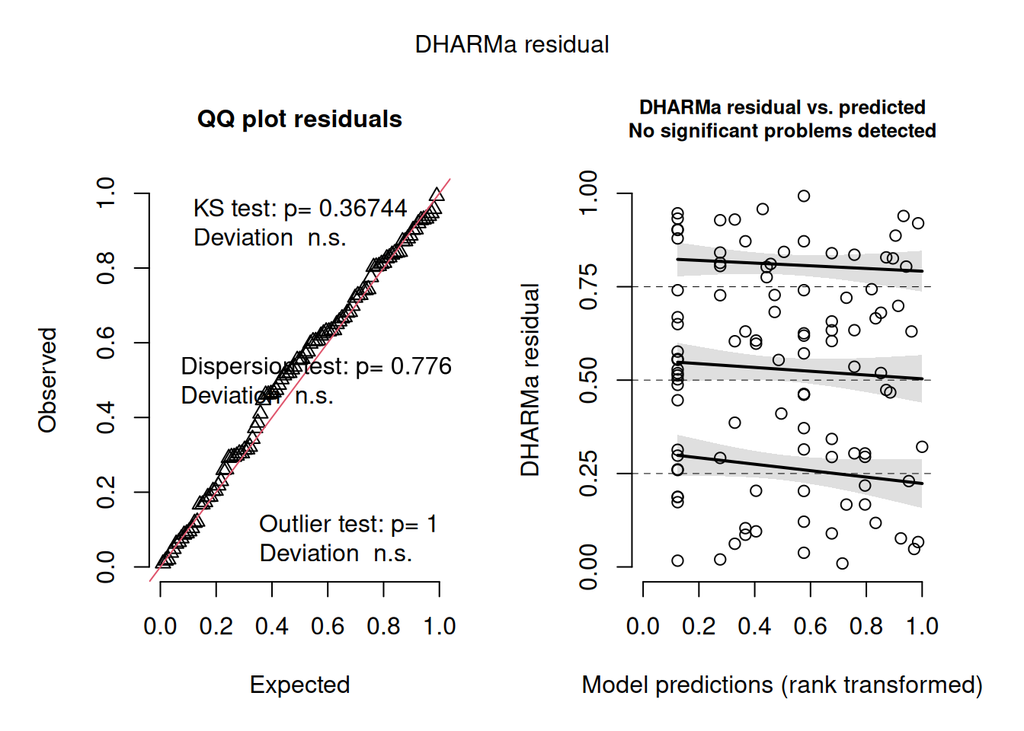

```r
simulationOutput_chicks <- simulateResiduals(fittedModel = glmer_prev_chicks_best, plot = F)
plot(simulationOutput_chicks)
```

We select `qPCR ~ Site + Ticks_by_nest + (1|Nest)` as the best-fitted model.  
**The site and the exposure to ticks are factors influencing the probability of infection of chicks.**

# 3.Dynamics of infection in chicks

```r
data_dyn <- read_excel("Data_Spatio-temporal patterns of infection_dynamics.xlsx")
data_dyn$Site <- as.factor(data_dyn$Site)
data_dyn$Sample <- as.factor(data_dyn$Sample)
data_dyn$Year <- as.factor(data_dyn$Year)
data_dyn$Age <- as.factor(data_dyn$Age)
data_dyn$Nest <- as.factor(data_dyn$Nest)
data_dyn$Sex <- as.factor(data_dyn$Sex)
data_dyn$Days <- as.numeric(data_dyn$Days)
data_dyn$Status_qPCR <- as.factor(data_dyn$Status_qPCR)
data_dyn$Ratio_qPCR <- as.numeric(data_dyn$Ratio_qPCR)
data_dyn$ErrorRatio_qPCR <- as.numeric(data_dyn$ErrorRatio_qPCR)
```

With:  
-Site: sampling colony (Carteau/Frioul)  
-Sample: ID of individual bird  
-Year: sampling year (2022/2023/2024)  
-Age: age of bird (Chick/Adult)  
-Nest: nest of bird  
-Sex: sex of bird (F/M)  
-Days: age in days of the chick at which the *Babesia* quantification was performed  
-Status_qPCR: infection status based on qPCR technique (uninfected/infected)  
-Ratio_qPCR: quantification of *Babesia* based on qPCR technique (ratio *Larus*/*Babesia* copies of genes)  
-ErrorRatio_qPCR: ratio error associated with `Ratio_qPCR`

**Important information:**  
This dataset includes only chicks monitored during 2024 because these individuals were monitored through several blood samples in order to perform *Babesia* quantification using qPCR technique.

We remove the missing values of variables that will be analysed in the model and we log-transform the values of `Ratio_qPCR`:

```r
data_dyn <- data_dyn[complete.cases(data_dyn[ , 10]),] #based on missing Status_qPCR
data_ratio <- data_dyn[complete.cases(data_dyn[ , 11]),] #based on missing Ratio_qPCR
data_ratio_no0 <- data_ratio[-which(data_ratio$Status_qPCR == "uninfected"),]

data_ratio_no0$log_ratioqPCR <- log10(data_ratio_no0$Ratio_qPCR)
```

## 3.1.GAM model

We include the variable `Days` (estimated age of the chick at the time of the infection) as a smooth term and the variables `Site` and `Sample` as random effects in our full GAM model:

```r
gam_model <- gam(log_ratioqPCR ~ s(Days) + s(Sample, bs = "re") + s(Site, bs = "re"), data = data_ratio_no0)
gam_model_null <- gam(log_ratioqPCR ~ 1 + s(Sample, bs = "re") + s(Site, bs = "re"), data = data_ratio_no0)
anova(gam_model, gam_model_null, test = "Chisq")
```

```
## Analysis of Deviance Table
##
## Model 1: log_ratioqPCR ~ s(Days) + s(Sample, bs = "re") + s(Site, bs = "re")
## Model 2: log_ratioqPCR ~ 1 + s(Sample, bs = "re") + s(Site, bs = "re")
##   Resid. Df Resid. Dev      Df Deviance  Pr(>Chi)
## 1    27.262     54.721
## 2    30.010     99.528 -2.7478  -44.806 1.261e-05 ***
## ---
## Signif. codes:  0 '***' 0.001 '**' 0.01 '*' 0.05 '.' 0.1 ' ' 1
```

```r
AIC(gam_model, gam_model_null)
```

```
##                      df      AIC
## gam_model      8.791208 139.2792
## gam_model_null 6.264542 156.9567
```

Based on ANOVA result and AICc values, **the best-fitted model is `log_ratioqPCR ~ s(Days) + s(Sample, bs = "re") + s(Site, bs = "re")`**.

We examine this model with different functions:

```r
summary(gam_model)
```

```
##
## Family: gaussian
## Link function: identity
##
## Formula:
## log_ratioqPCR ~ s(Days) + s(Sample, bs = "re") + s(Site, bs = "re")
##
## Parametric coefficients:
##             Estimate Std. Error t value Pr(>|t|)
## (Intercept)  -5.3171     0.4372  -12.16  3.6e-13 ***
## ---
## Signif. codes:  0 '***' 0.001 '**' 0.01 '*' 0.05 '.' 0.1 ' ' 1
##
## Approximate significance of smooth terms:
##              edf Ref.df     F  p-value
## s(Days)   3.4902  4.308 6.376 0.000628 ***
## s(Sample) 2.7276 13.000 0.289 0.242677
## s(Site)   0.5734  1.000 2.084 0.129092
## ---
## Signif. codes:  0 '***' 0.001 '**' 0.01 '*' 0.05 '.' 0.1 ' ' 1
##
## R-sq.(adj) =  0.493   Deviance explained = 58.6%
## GCV = 2.2786  Scale est. = 1.8114    n = 38
```

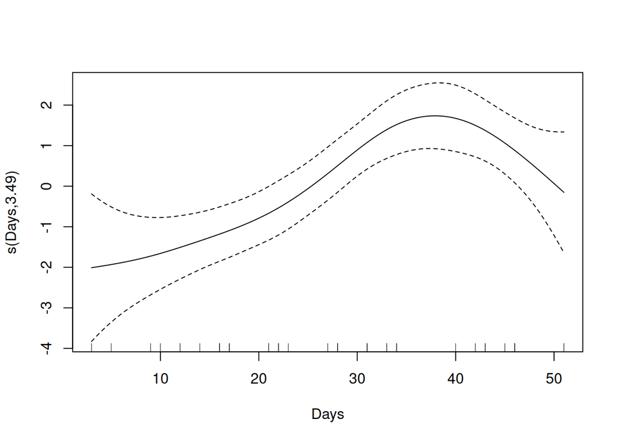

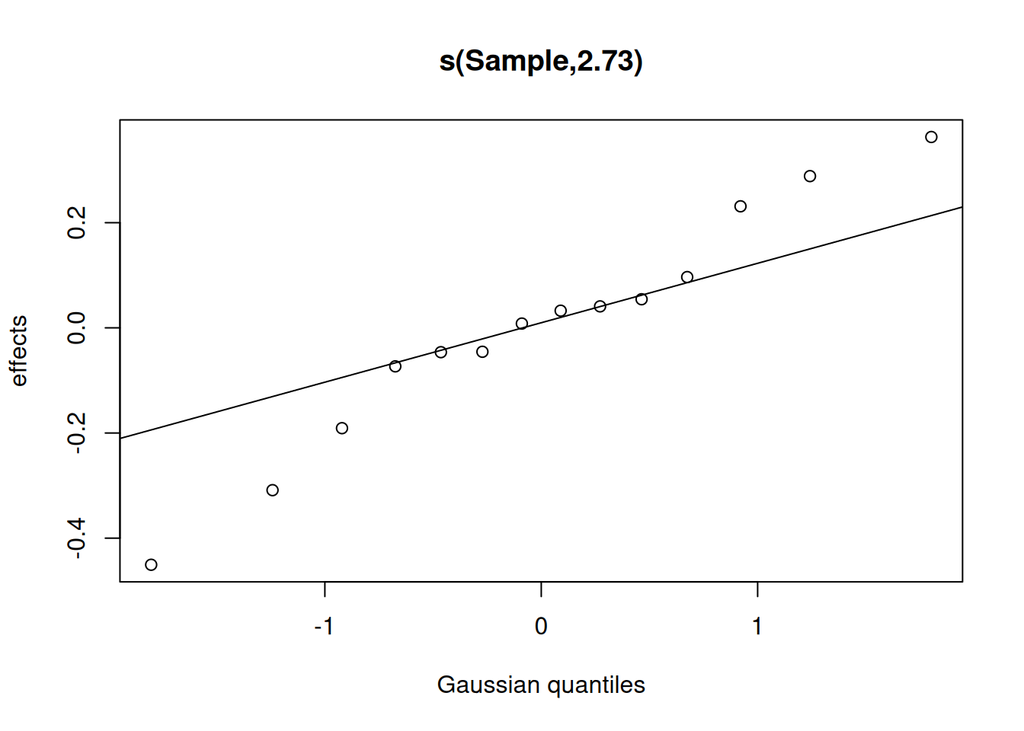

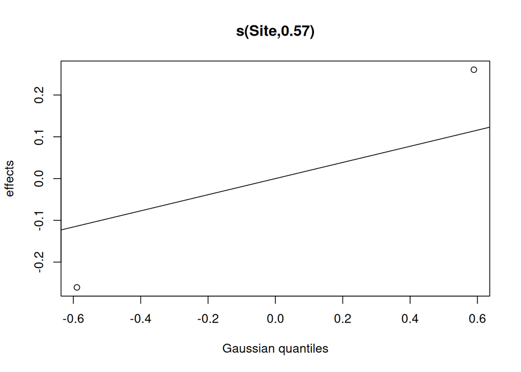

```r
plot(gam_model)
```

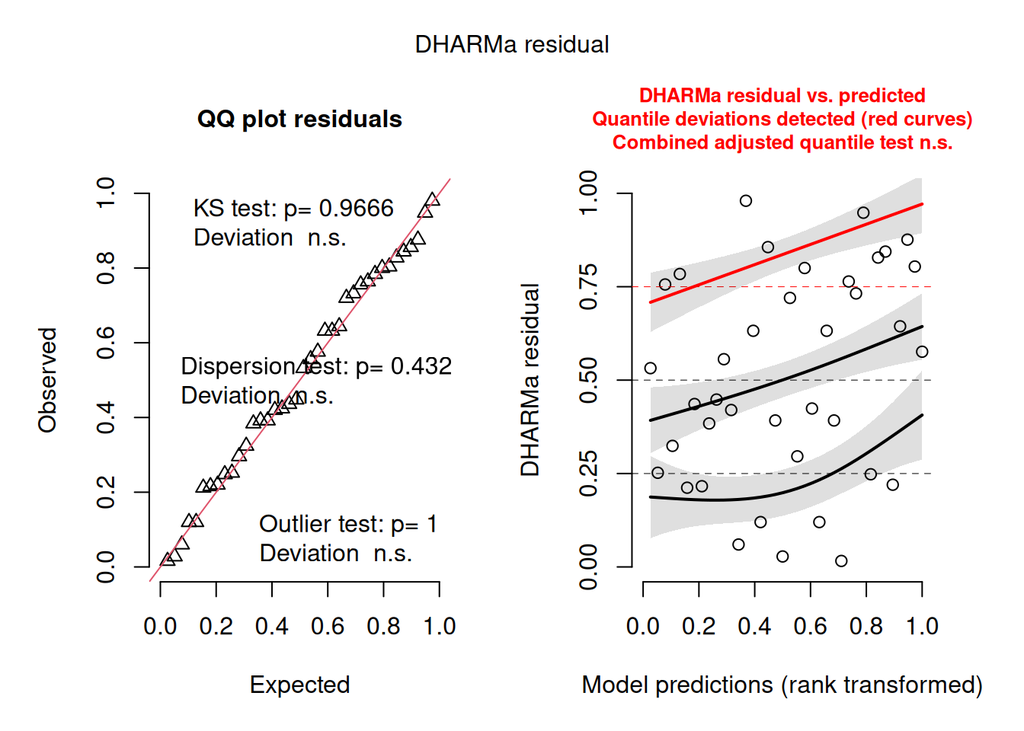

```r
simulationOutput_gam <- simulateResiduals(fittedModel = gam_model)
plot(simulationOutput_gam)
```

**The parasitemia changes over the growth of chicks (p-value = 0.000628 with R-sq.(adj) = 0.493).**

To develop this analysis, we identify at which day the parasitemia is decreasing based on the derivative values:

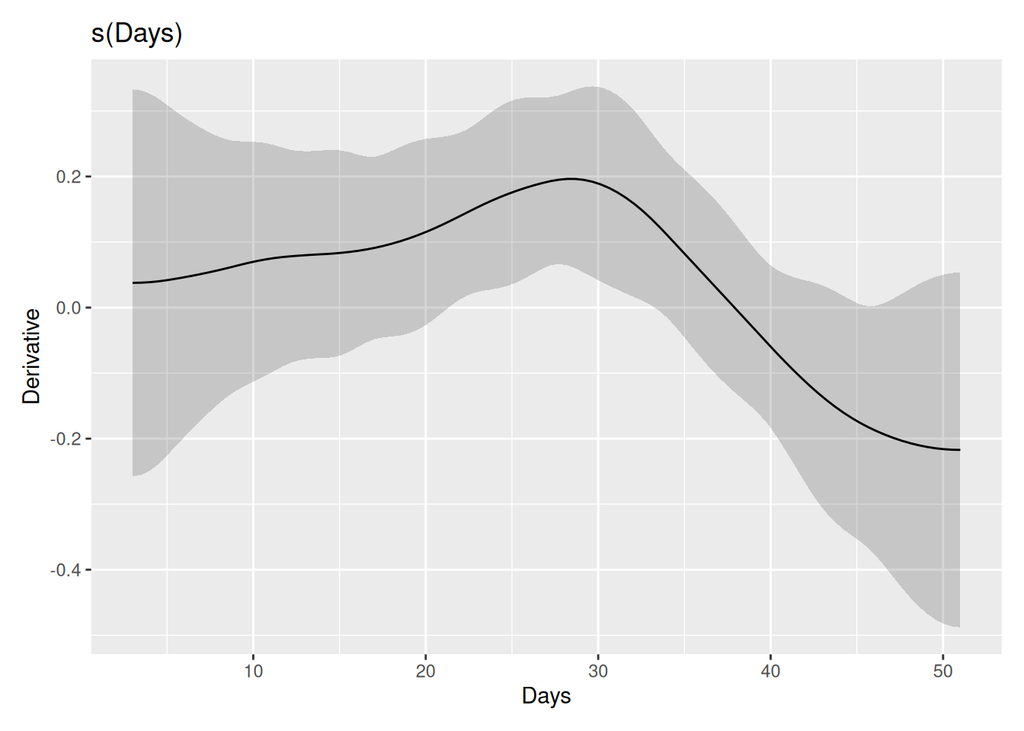

```r
derivs <- derivatives(gam_model, term = "s(Days)", type = "central")
draw(derivatives(gam_model, term = "s(Days)"))
```

## 3.2.Visualisation

Here is a visualisation of the data with the model:

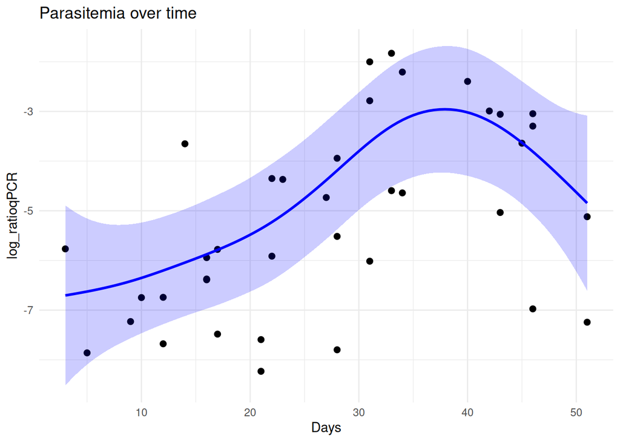

```r
# Generate new data for predictions
gam_data <- data.frame(
  Days = seq(min(data_ratio_no0$Days), max(data_ratio_no0$Days), length.out = 100),
  Sample = levels(data_ratio_no0$Sample)[1], # Example: First level of Sample
  Site = levels(data_ratio_no0$Site)[1]      # Example: First level of Site
)

# Predictions including random effects, with standard errors
predictions <- predict(gam_model, newdata = gam_data, type = "link", se.fit = TRUE, re.form = NULL)

# Add predictions and confidence intervals to the dataframe
gam_data$fit <- predictions$fit                      # Predicted values
gam_data$se.fit <- predictions$se.fit                # Standard errors
gam_data$lower <- gam_data$fit - 1.96 * gam_data$se.fit  # Lower bound of CI
gam_data$upper <- gam_data$fit + 1.96 * gam_data$se.fit  # Upper bound of CI

ggplot() +
  geom_point(data = data_ratio_no0, aes(x = Days, y = log_ratioqPCR), size = 2) +
  geom_line(data = gam_data, aes(x = Days, y = fit), color = "blue", size = 1) +
  geom_ribbon(data = gam_data, aes(x = Days, ymin = lower, ymax = upper), alpha = 0.2, fill = "blue") +
  theme_minimal() +
  labs(x = "Days", y = "log_ratioqPCR", title = "Parasitemia over time")
```

## 3.3.Complementary test to assess a potential effect of Sex

We additionally examine if the variable `Sex` could impact the model:

```r
gam_model_full <- gam(log_ratioqPCR ~ s(Days) + Sex + s(Sample, bs = "re") + s(Site, bs = "re"), data = data_ratio_no0)
gam_model_sex <- gam(log_ratioqPCR ~ Sex + s(Sample, bs = "re") + s(Site, bs = "re"), data = data_ratio_no0)
gam_model_days <- gam(log_ratioqPCR ~ s(Days) + s(Sample, bs = "re") + s(Site, bs = "re"), data = data_ratio_no0)
gam_model_null <- gam(log_ratioqPCR ~ 1 + s(Sample, bs = "re") + s(Site, bs = "re"), data = data_ratio_no0)

AIC(gam_model_full, gam_model_sex, gam_model_days, gam_model_null)
```

```
##                      df      AIC
## gam_model_full 9.705949 139.9858
## gam_model_sex  6.494098 156.7699
## gam_model_days 8.791208 139.2792
## gam_model_null 6.264542 156.9567
```

```r
anova(gam_model_full, gam_model_days, test = "Chisq")
```

```
## Analysis of Deviance Table
##
## Model 1: log_ratioqPCR ~ s(Days) + Sex + s(Sample, bs = "re") + s(Site,
##     bs = "re")
## Model 2: log_ratioqPCR ~ s(Days) + s(Sample, bs = "re") + s(Site, bs = "re")
##   Resid. Df Resid. Dev       Df Deviance Pr(>Chi)
## 1    26.411     53.128
## 2    27.262     54.721 -0.85102  -1.5933   0.2969
```

Even if AICc values are close between model full (139.9858) and model days (139.2792), there is no significant difference based on ANOVA.

**`Sex` is not a significant fixed effect to explain parasitemia over time.**